# Proposal

cyber-atlas

April 2, 2019

Gets us the packages that we need to get the data. We are using the Quantmod library as of now

```r
# install.packages("quantmod")
library(quantmod)
```

```r
library(ggplot2)
```

The start and endates for these samples. It pulls data based on the day. I need to see if it is possible to find stuff for intraday trading, but this helps us get started for now.

```r
#Define start and End dates
start <- as.Date("2018-01-01")
end <- as.Date("2019-04-23")
```

Get some of the symbols that we will be looking at in the timefram that we are looking at.

```r
?getSymbols
```

```
## starting httpd help server ... done
```

```r
AMD2 <- getSymbols("AMD", src = "yahoo", from = "2017-01-01", to = "2019-04-20", auto.assign = FALSE)
```

[output not shown]

```r
#I tried to add SOX but it failed, I might have the symbol wrong...
getSymbols(c("AAPL", "AMD", "SPY", "MU"), src="yahoo", from = start, to = end)
```

```
## [1] "AAPL" "AMD"  "SPY"  "MU"
```

We ran into issues getting SOX to import, I probably goofed and got the wrong symbol.

The data is saved as an xts object. From what I could tell it is very similar to a dataframe except it has more fields. Also showing some of the data.

```r
class(AMD)
```

```
## [1] "xts" "zoo"
```

```r
head(AMD)
```

```
##            AMD.Open AMD.High AMD.Low AMD.Close AMD.Volume AMD.Adjusted
## 2018-01-02    10.42    11.02   10.34     10.98   44146300        10.98
## 2018-01-03    11.61    12.14   11.36     11.55  154066700        11.55
## 2018-01-04    12.10    12.43   11.97     12.12  109503000        12.12
## 2018-01-05    12.19    12.22   11.66     11.88   63808900        11.88
## 2018-01-08    12.01    12.30   11.85     12.28   63346000        12.28
## 2018-01-09    12.00    12.02   11.71     11.82   62560900        11.82
```

```r
tail(AMD)
```

```
##            AMD.Open AMD.High AMD.Low AMD.Close AMD.Volume AMD.Adjusted
## 2019-04-12    28.21    28.38   27.66     27.85   41048800        27.85
## 2019-04-15    27.80    27.84   26.96     27.33   40812500        27.33
## 2019-04-16    27.72    28.18   27.49     27.93   47340100        27.93
## 2019-04-17    28.21    28.27   27.22     27.49   48240800        27.49
## 2019-04-18    27.60    27.88   27.34     27.68   39880900        27.68
## 2019-04-22    27.62    28.23   27.39     28.18   36414200        28.18
```

```r
head(SPY)
```

```
##            SPY.Open SPY.High SPY.Low SPY.Close SPY.Volume SPY.Adjusted
## 2018-01-02   267.84   268.81  267.40    268.77   86655700     262.6032
## 2018-01-03   268.96   270.64  268.96    270.47   90070400     264.2642
## 2018-01-04   271.20   272.16  270.54    271.61   80636400     265.3781
## 2018-01-05   272.51   273.56  271.95    273.42   83524000     267.1465
## 2018-01-08   273.31   274.10  272.98    273.92   57319200     267.6351
## 2018-01-09   274.40   275.25  274.08    274.54   57254000     268.2409
```

```r
tail(SPY)
```

```
##            SPY.Open SPY.High SPY.Low SPY.Close SPY.Volume SPY.Adjusted
## 2019-04-12   290.00   290.47  288.26    290.16   69727800       290.16
## 2019-04-15   290.24   290.35  289.08    289.97   49596700       289.97
## 2019-04-16   290.95   291.01  289.50    290.16   52153200       290.16
## 2019-04-17   291.40   291.43  288.99    289.45   58268300       289.45
## 2019-04-18   290.10   290.32  288.66    290.02   68708500       290.02
## 2019-04-22   289.17   290.44  289.07    290.27   40001900       290.27
```

```r
head(MU)
```

```
##            MU.Open MU.High MU.Low MU.Close MU.Volume MU.Adjusted
## 2018-01-02   41.54   43.72  41.19    43.67  37097000       43.67
## 2018-01-03   44.50   45.05  44.05    44.98  43376700       44.98
## 2018-01-04   45.99   46.98  45.01    46.88  52229500       46.88
## 2018-01-05   46.13   46.66  45.38    45.80  47381100       45.80
## 2018-01-08   45.31   46.09  44.91    45.55  32217400       45.55
## 2018-01-09   45.27   45.55  42.77    42.97  62982900       42.97
```

```r
tail(MU)
```

```
##            MU.Open MU.High MU.Low MU.Close MU.Volume MU.Adjusted
## 2019-04-12   42.85   43.20  41.81    42.01  21740400       42.01
## 2019-04-15   42.17   42.23  41.20    41.82  16932300       41.82
## 2019-04-16   42.26   42.93  42.08    42.76  19337500       42.76
## 2019-04-17   43.36   44.05  42.76    43.15  22092000       43.15
## 2019-04-18   43.20   43.53  42.79    43.40  16193600       43.40
## 2019-04-22   43.14   43.57  42.53    43.40  19440300       43.40
```

```r
names(MU)
```

```
## [1] "MU.Open"     "MU.High"     "MU.Low"      "MU.Close"    "MU.Volume"
## [6] "MU.Adjusted"
```

Let’s plot the stock data

The close prices of Apple over the given timeframe

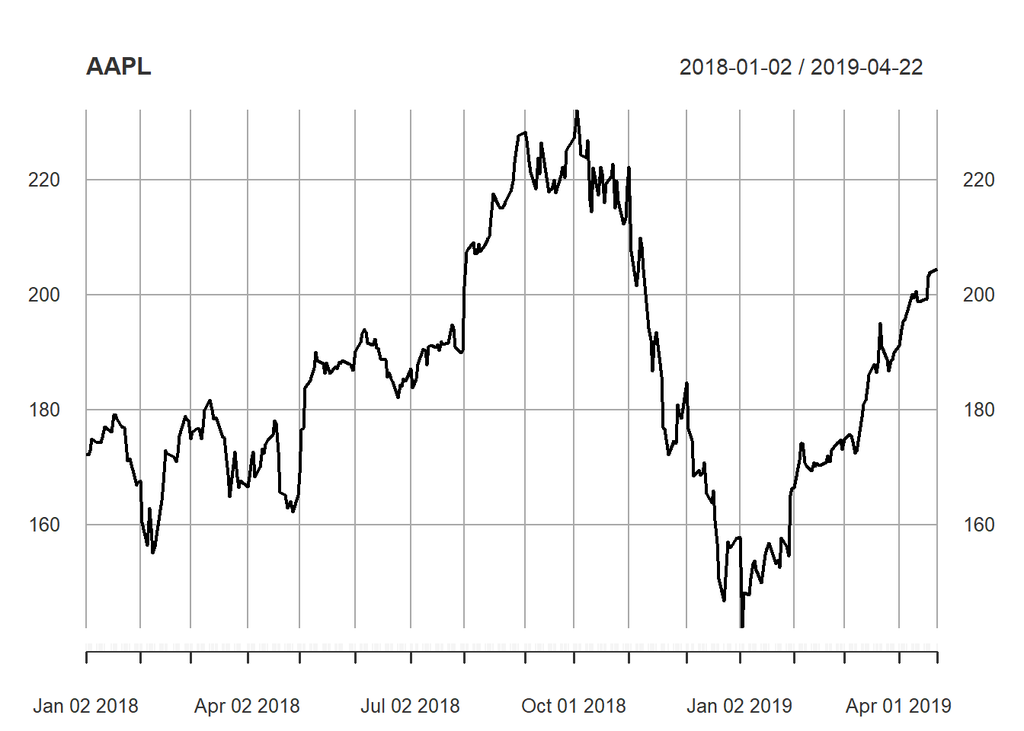

```r
plot(AAPL[, "AAPL.Close"], main = "AAPL")
```

Another way to plot, this time using the AMD close prices

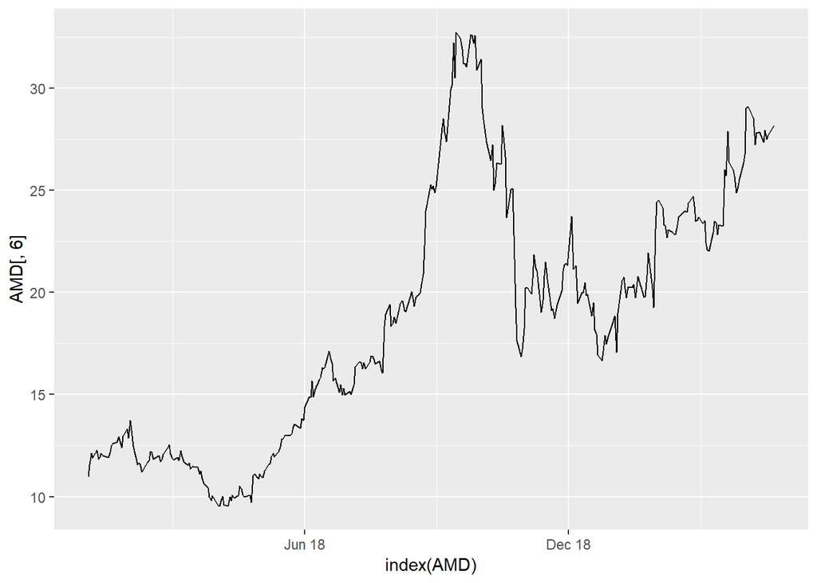

```r
amd.df<- data.frame(AMD)

ggplot(AMD, aes(x=index(AMD), y=AMD[,6]))+geom_line(color="black")+scale_x_date(date_labels = "%b %y", date_breaks = "6 months")
```

Line charts are great and all but candlestick charts are more used and more useful.

This is the candle stick chart for MU

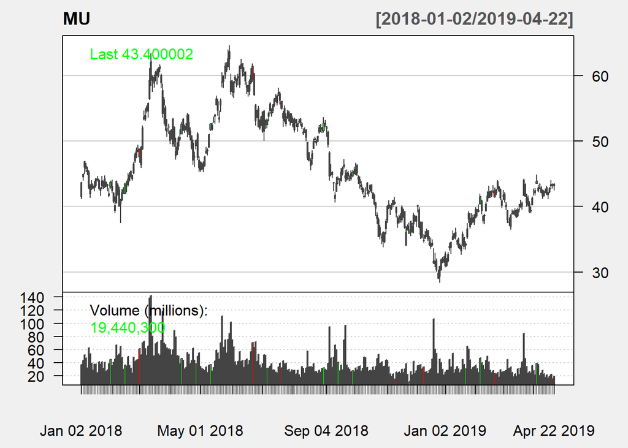

```r
candleChart(MU, up.col = "green", dn.col = "red", theme = "white")
```